# All Projects

Berkay Zühre

October 1, 2020

## IE48A - Introduction to Data Analytics Course

Instructor: Berk Orbay

We were expected to perform end to end reproducible data analysis from raw data to the communication of model outputs.

R was the primary language used in the course.

Course Projects:

- [R Plumber Package for API Generation Tutorial Video](https://www.youtube.com/watch?v=XI2Mi9ogRQc&feature=youtu.be/)
- [Final Project Report](https://pjournal.github.io/boun01g-hisrustu/FinalReport.html)
- [Group Project Shiny App Link](https://faruktufekci.shinyapps.io/boun01g-hisrustu-project-housing-data/)

## IE423 - Quality Engineering - Image Processing Project

Instructor: Mustafa Gökçe Baydogan

I learned the fundemental statictical approaches used in quality engineering. The final group project was to develop an image processing model from scratch on a linen manufacturing data. We tried to predict the defects in linen products from photos.

Python was the primary language used in the course.

Course Projects:

- [All Parts of the Project](https://bu-ie-582.github.io/fall19-akinelden/)
- [Final Image Processing Part](https://bu-ie-582.github.io/fall19-akinelden/Project_Part3/Part3)

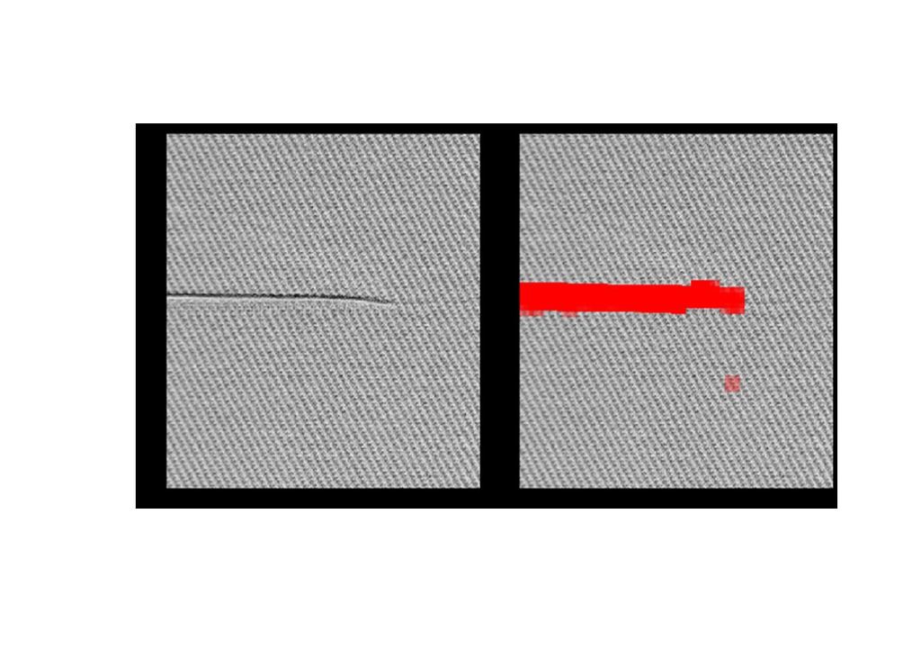

## CMPE321 - Introduction to Database Systems

Instructor: Taflan Gündem

This course had covered two main subjects. The first one was to design and code a Database Management System with System Catalog, file, page and record structures implemented. The second part was to design a Library Web Page where you can add, delete or borrow books from the system.

I used Shiny Package in R for the web page and SQLite for the database.

Course Projects:

- [Library Web Page](https://berkayzuhre.github.io/LibraryDB/LibraryDBDocumentation.html)

## CMPE250 - Data Structures and Algorithms

Instructor: Ali Taylan Cemgil

This is a fundemental course for computer science which covered the important algorithms and their implementation. This course had 5 different projects.

C++ was the primary language used in the course.

Course Projects:

- [Project Explanations and Github Links](https://berkayzuhre.github.io/Shortest_Ladder/CMPE250.html)

## IE201 - Intermediate Programming and Object Oriented Design

Instructor: Ali Tamer Ünal

The first part of this course is focused on how an Object Oriented Program should be designed and modelled. The second part is the actual implementation and a basic introuction to Data Structures and Algorithms.

C++ was the primary language used in the course. Also UML was used for modelling.

Course Projects:

- [Final Project Code and UML Models](https://github.com/berkayzuhre/Object-Oriented-Car-Game)

## Personal Project - Projectile Motion Simulation

I have created a cannon that randomly fires different types of projectiles towards a house. The housefolk record projectile positions in certain times and try to predict where it will pass so they can hit them mid air.

C++ was used for the simulation and R was used for the forecasting model.

- [Github Page](https://github.com/berkayzuhre/Projectile-Motion)

[figure not shown]

## Personal Project - Pacman

I have implemented Breadth First Search Algorithm to calculate the shortest path with C++ so the Monsters can chase the Pacman.

C++ was used for the game.

- [Github Page](https://github.com/berkayzuhre/Pac_Man_Console_Game)

[figure not shown]